# Auto-generated report

Xijin Ge @SDSU

2023-05-17

### Step 1

Prompt: Write R code, without explanation, following these instructions. the first task is to retrieve stock price data for the SPDR S&P 500 Trust ETF (SPY) for Jan. 1, 2012 to Dec. 31, 2022 using a suitable R package such as quantmod or tidyquant. This can be achieved by loading the package and using the getSymbols() function to retrieve the data from a financial data provider such as Yahoo Finance. The function should be configured to specify the SPY ticker symbol, the start date, and the end date of the data to be retrieved. Show the first few lines of data.

```r
pacman::p_load(quantmod)
getSymbols("SPY", from = "2012-01-01", to = "2022-12-31")
```

```
## [1] "SPY"
```

```r
head(SPY)
```

```
##            SPY.Open SPY.High SPY.Low SPY.Close SPY.Volume SPY.Adjusted
## 2012-01-03   127.76   128.38  127.43    127.50  193697900     103.2023
## 2012-01-04   127.20   127.81  126.71    127.70  127186500     103.3642
## 2012-01-05   127.01   128.23  126.43    128.04  173895000     103.6394
## 2012-01-06   128.20   128.22  127.29    127.71  148050000     103.3723
## 2012-01-09   128.00   128.18  127.41    128.02   99530200     103.6232
## 2012-01-10   129.39   129.65  128.95    129.13  115282000     104.5217
```

### Step 2

Prompt: Write R code, without explanation, following these instructions. Plot the stock data with 20, 50, and 200 day moving averages

```r
pacman::p_load(quantmod)
getSymbols("SPY", from = "2012-01-01", to = "2022-12-31")
```

```
## [1] "SPY"
```

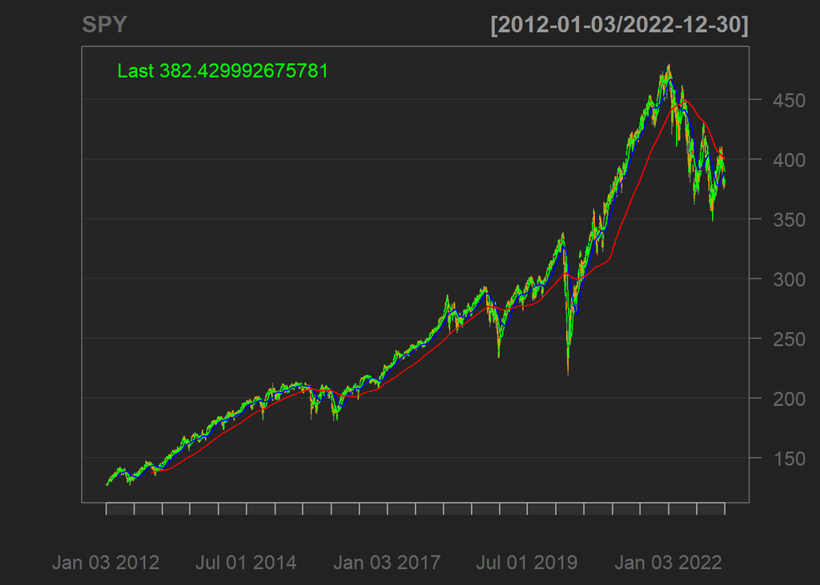

```r
SMA20 <- SMA(Cl(SPY), n = 20)
SMA50 <- SMA(Cl(SPY), n = 50)
SMA200 <- SMA(Cl(SPY), n = 200)
chartSeries(SPY, TA = c(addSMA(n = 20, col = "green"), addSMA(n = 50, col = "blue"), addSMA(n = 200, col = "red")))
```

### Step 3

Prompt: Write R code, without explanation, following these instructions. To identify suitable buy and sell signals, a buy signal occurs when the 50-day crosses above the 200-day. A sell signal occurs when the 50-day drops below the 200-day.  
Write the data into a CSV file.

```r
pacman::p_load(quantmod)
getSymbols("SPY", from = "2012-01-01", to = "2022-12-31", auto.assign = TRUE)
```

```
## [1] "SPY"
```

```r
SMA50 <- SMA(Cl(SPY), n = 50)
SMA200 <- SMA(Cl(SPY), n = 200)
buySignal <- Lag(ifelse(SMA50 >= SMA200, 1, 0))
sellSignal <- Lag(ifelse(SMA50 < SMA200, -1, 0))
signal <- buySignal + sellSignal
signal[is.na(signal)] <- 0
df <- data.frame(Date = index(SPY), Close = SPY$SPY.Close, Signal = signal)
write.csv(df, "SPY_Signal.csv", row.names = FALSE)
```

### Step 4

Prompt: Write R code, without explanation, following these instructions. let suppose we have a a total of $10,000. We buy at the first buy signal and sell at the next sell signal. Calculate the total return over the period.

```r
pacman::p_load(quantmod)
getSymbols("SPY", from = "2012-01-01", to = "2022-12-31", auto.assign = TRUE)
```

```
## [1] "SPY"
```

```r
SMA50 <- SMA(Cl(SPY), n = 50)
SMA200 <- SMA(SPY$SPY.Adjusted, n = 200)
buySignal <- Lag(ifelse(SMA50 >= SMA200, 1, 0))
sellSignal <- Lag(ifelse(SMA50 < SMA200, -1, 0))
signal <- buySignal + sellSignal
signal[is.na(signal)] <- 0

initial_funds <- 10000
fund <- initial_funds
cash <- 0
shares <- 0

for (i in 1:length(signal)) {
  if (signal[i] == 1 && cash == 0) {
    shares <- fund / as.numeric(SPY$SPY.Adjusted[i])
    cash <- fund
    fund <- 0
  } else if (signal[i] == -1 && fund == 0) {
    fund <- shares * as.numeric(SPY$SPY.Adjusted[i])
    cash <- 0
    shares <- 0
  }
}

if (fund == 0 && shares != 0) {
  fund <- shares * as.numeric(SPY$SPY.Adjusted[length(SPY$SPY.Adjusted)])
}

total_return <- (fund - initial_funds) / initial_funds * 100
total_return
```

```
## [1] 204.7272
```

### Step 5

Prompt: Write R code, without explanation, following these instructions. Calculate the return of SPY during the same period.

```r
pacman::p_load(quantmod)
getSymbols("SPY", from = "2012-01-01", to = "2022-12-31", auto.assign = TRUE)
```

```
## [1] "SPY"
```

```r
initial_funds <- 10000
total_return <- (as.numeric(SPY$SPY.Adjusted[length(SPY$SPY.Adjusted)]) - as.numeric(SPY$SPY.Adjusted[1])) / as.numeric(SPY$SPY.Adjusted[1]) * 100
total_return
```

```
## [1] 269.1545
```

### Step 6

Prompt: Write R code, without explanation, following these instructions. Reevaluate the performance of another trading strategy. A buy signal occurs when the 10-day moving average crosses above the 50-day moving average. A sell signal occurs when the 10-day drops below the 50-day.

```r
pacman::p_load(quantmod)
getSymbols("SPY", from = "2012-01-01", to = "2022-12-31", auto.assign = TRUE)
```

```
## [1] "SPY"
```

```r
SMA10 <- SMA(Cl(SPY), n = 10)
SMA50 <- SMA(Cl(SPY), n = 50)
buySignal <- Lag(ifelse(SMA10 >= SMA50, 1, 0))
sellSignal <- Lag(ifelse(SMA10 < SMA50, -1, 0))
signal <- buySignal + sellSignal
signal[is.na(signal)] <- 0

initial_funds <- 10000
fund <- initial_funds
cash <- 0
shares <- 0

for (i in 1:length(signal)) {
  if (signal[i] == 1 && cash == 0) {
    shares <- fund / as.numeric(SPY$SPY.Adjusted[i])
    cash <- fund
    fund <- 0
  } else if (signal[i] == -1 && fund == 0) {
    fund <- shares * as.numeric(SPY$SPY.Adjusted[i])
    cash <- 0
    shares <- 0
  }
}

if (fund == 0 && shares != 0) {
  fund <- shares * as.numeric(SPY$SPY.Adjusted[length(SPY$SPY.Adjusted)])
}

total_return <- (fund - initial_funds) / initial_funds * 100
total_return
```

```
## [1] 77.7057
```

### Step 7

Prompt: Write R code, without explanation, following these instructions. Evaluate the performance of this trading strategy over time.

```r
pacman::p_load(quantmod)
getSymbols("SPY", from = "2012-01-01", to = "2022-12-31", auto.assign = TRUE)
```

```
## [1] "SPY"
```

```r
SMA10 <- SMA(Cl(SPY), n = 10)
SMA50 <- SMA(Cl(SPY), n = 50)
buySignal <- Lag(ifelse(SMA10 >= SMA50, 1, 0))
sellSignal <- Lag(ifelse(SMA10 < SMA50, -1, 0))
signal <- buySignal + sellSignal
signal[is.na(signal)] <- 0

initial_funds <- 10000
fund <- initial_funds
cash <- 0
shares <- 0
return_vec <- c()
signal_vec <- c()

for (i in 1:length(signal)) {
  if (signal[i] == 1 && cash == 0) {
    shares <- fund / as.numeric(SPY$SPY.Adjusted[i])
    cash <- fund
    fund <- 0
    signal_vec <- append(signal_vec, "Buy")
  } else if (signal[i] == -1 && fund == 0) {
    fund <- shares * as.numeric(SPY$SPY.Adjusted[i])
    cash <- 0
    shares <- 0
    signal_vec <- append(signal_vec, "Sell")
  } else {
    signal_vec <- append(signal_vec, "Hold")
  }
  return_vec <- append(return_vec, (fund + shares * as.numeric(SPY$SPY.Adjusted[i])) / initial_funds * 100)
}

df <- data.frame(Date = index(SPY), Signal = signal_vec, Return = return_vec)
head(df)
```

```
##         Date Signal Return
## 1 2012-01-03   Hold    100
## 2 2012-01-04   Hold    100
## 3 2012-01-05   Hold    100
## 4 2012-01-06   Hold    100
## 5 2012-01-09   Hold    100
## 6 2012-01-10   Hold    100
```

### Step 8

Prompt: Write R code, without explanation, following these instructions. Plot this performance along side SPY.

```r
pacman::p_load(quantmod)
getSymbols("SPY", from = "2012-01-01", to = "2022-12-31", auto.assign = TRUE)
```

```
## [1] "SPY"
```

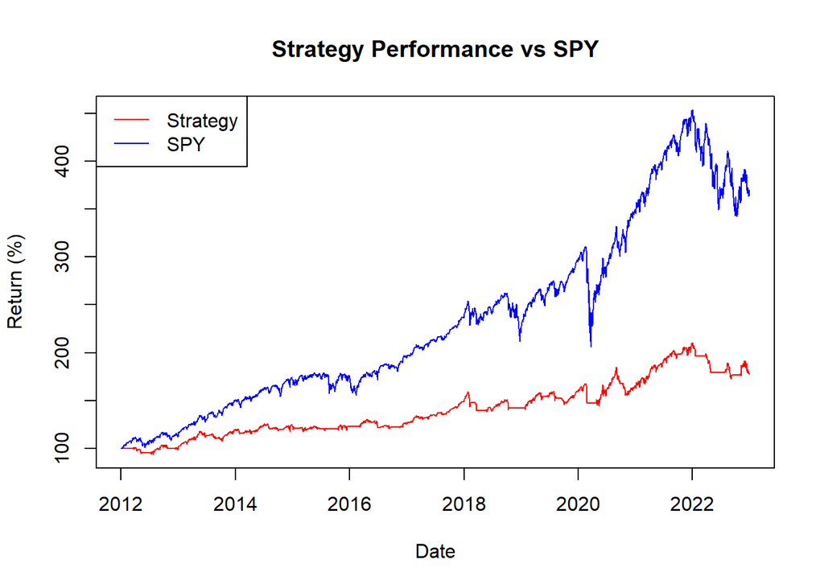

```r
SMA10 <- SMA(Cl(SPY), n = 10)
SMA50 <- SMA(Cl(SPY), n = 50)
buySignal <- Lag(ifelse(SMA10 >= SMA50, 1, 0))
sellSignal <- Lag(ifelse(SMA10 < SMA50, -1, 0))
signal <- buySignal + sellSignal
signal[is.na(signal)] <- 0

initial_funds <- 10000
fund <- initial_funds
cash <- 0
shares <- 0
return_vec <- c()

for (i in 1:length(signal)) {
  if (signal[i] == 1 && cash == 0) {
    shares <- fund / as.numeric(SPY$SPY.Adjusted[i])
    cash <- fund
    fund <- 0
  } else if (signal[i] == -1 && fund == 0) {
    fund <- shares * as.numeric(SPY$SPY.Adjusted[i])
    cash <- 0
    shares <- 0
  }
  return_vec <- append(return_vec, (fund + shares * as.numeric(SPY$SPY.Adjusted[i])) / initial_funds * 100)
}

df <- data.frame(Date = index(SPY), Return = return_vec)

spy_returns <- (SPY$SPY.Adjusted / as.numeric(SPY$SPY.Adjusted[1])) * 100

plot(df$Date, df$Return, col = "red", type = "l", ylim = c(min(c(df$Return, spy_returns)), max(c(df$Return, spy_returns))), xlab = "Date", ylab = "Return (%)", main = "Strategy Performance vs SPY")
lines(df$Date, spy_returns, col = "blue")
legend("topleft", legend = c("Strategy", "SPY"), col = c("red", "blue"), lty = 1)
```